# Practical Machine Learning: Prediction Assignment

Apr 8, 2020

## Background

Goal of this project is to develop a prediction model for dumbbell movements of 6 participants who lifted dumbbells correctly and incorrectly in 5 different ways. More information is available on the [Weight Lifting Exercise Dataset](http://groupware.les.inf.puc-rio.br/har)

## Data

1. [Training Data](https://d396qusza40orc.cloudfront.net/predmachlearn/pml-training.csv)
2. [Testing Data](https://d396qusza40orc.cloudfront.net/predmachlearn/pml-testing.csv)

## Analyses

Use dumbbell movement data to classify the movements into 5 cateories: Class A is the correct movement; Class B is throwing elbows to front; Class C is lifting dumbbells only halfway; Class D is lowering dumbbells halfway; and Class E is throwing hips to the front. Ultimately the final algorithm will be used to classify movement of 20 observations in the testing data.

## Review data and clean in prep for Cross Validation

```r
library(caret); library(ggplot2)
set.seed(4889)
pmltrain = read.csv("pml-training.csv", na.string=c("NA", "#DIV/0!", ""))
pmltest = read.csv("pml-testing.csv", na.string=c("NA", "#DIV/0!", ""))
str(pmltrain); str(pmltest)
 #looks like a lot of missing; 13737 observations 160 variables; 20 observations 160 variables
table(pmltrain$classe)

##clean to have most complete data; ie no missing
misstrain <- sapply(pmltrain, function(x){any(is.na(x))})
pmltrain <- pmltrain[,!misstrain]
names(pmltrain)

misstest <- sapply(pmltest, function(x){any(is.na(x))})
pmltest <- pmltest[, !misstest]
names(pmltest)
```

## create cross validation subsets (train and test datasets)

```r
inTrain <- createDataPartition(y=pmltrain$classe, p=0.7, list=FALSE)
train = pmltrain[inTrain,]
test <- pmltrain[-inTrain,]
```

The training set has 13737 observations with 60 variables The test set has 5885 observations with 60 variables

## see if any variables have no variability

```r
nsv <-nearZeroVar(train, saveMetrics = TRUE)
nsv
```

```
##                      freqRatio percentUnique zeroVar   nzv
## X                     1.000000  100.00000000   FALSE FALSE
## user_name             1.067460    0.04367766   FALSE FALSE
## raw_timestamp_part_1  1.133333    6.09303341   FALSE FALSE
## raw_timestamp_part_2  1.250000   89.45184538   FALSE FALSE
## cvtd_timestamp        1.011472    0.14559220   FALSE FALSE
## new_window           47.031469    0.01455922   FALSE  TRUE
## num_window            1.133333    6.24590522   FALSE FALSE
## roll_belt             1.234676    8.05852806   FALSE FALSE
## pitch_belt            1.000000   12.36805707   FALSE FALSE
## yaw_belt              1.081006   13.20521220   FALSE FALSE
## total_accel_belt      1.071100    0.20382907   FALSE FALSE
## gyros_belt_x          1.073499    0.96090850   FALSE FALSE
## gyros_belt_y          1.151252    0.48773386   FALSE FALSE
## gyros_belt_z          1.049600    1.15745796   FALSE FALSE
## accel_belt_x          1.078995    1.16473757   FALSE FALSE
## accel_belt_y          1.076364    0.98274732   FALSE FALSE
## accel_belt_z          1.052464    2.14020528   FALSE FALSE
## magnet_belt_x         1.103175    2.25667904   FALSE FALSE
## magnet_belt_y         1.104213    2.12564607   FALSE FALSE
## magnet_belt_z         1.093656    3.20302832   FALSE FALSE
## roll_arm             51.468085   17.56569848   FALSE FALSE
## pitch_arm            83.413793   20.33922982   FALSE FALSE
## yaw_arm              32.689189   19.12353498   FALSE FALSE
## total_accel_arm       1.029688    0.47317464   FALSE FALSE
## gyros_arm_x           1.021505    4.54975613   FALSE FALSE
## gyros_arm_y           1.457534    2.62793914   FALSE FALSE
## gyros_arm_z           1.055409    1.74710636   FALSE FALSE
## accel_arm_x           1.033333    5.59801995   FALSE FALSE
## accel_arm_y           1.121019    3.82179515   FALSE FALSE
## accel_arm_z           1.045977    5.49610541   FALSE FALSE
## magnet_arm_x          1.015873    9.51445003   FALSE FALSE
## magnet_arm_y          1.000000    6.22406639   FALSE FALSE
## magnet_arm_z          1.123457    9.10679188   FALSE FALSE
## roll_dumbbell         1.054945   86.86030429   FALSE FALSE
## pitch_dumbbell        2.461538   84.53810876   FALSE FALSE
## yaw_dumbbell          1.123457   86.31433355   FALSE FALSE
## total_accel_dumbbell  1.089005    0.30574361   FALSE FALSE
## gyros_dumbbell_x      1.063679    1.71070831   FALSE FALSE
## gyros_dumbbell_y      1.225728    1.95093543   FALSE FALSE
## gyros_dumbbell_z      1.038369    1.42680352   FALSE FALSE
## accel_dumbbell_x      1.008547    2.96280119   FALSE FALSE
## accel_dumbbell_y      1.132530    3.32678168   FALSE FALSE
## accel_dumbbell_z      1.309677    2.91912353   FALSE FALSE
## magnet_dumbbell_x     1.081301    7.75278445   FALSE FALSE
## magnet_dumbbell_y     1.161290    5.94016161   FALSE FALSE
## magnet_dumbbell_z     1.047619    4.84094053   FALSE FALSE
## roll_forearm         11.216667   13.62014996   FALSE FALSE
## pitch_forearm        58.478261   19.21816991   FALSE FALSE
## yaw_forearm          16.303030   12.94314625   FALSE FALSE
## total_accel_forearm   1.102623    0.48773386   FALSE FALSE
## gyros_forearm_x       1.048000    2.04557036   FALSE FALSE
## gyros_forearm_y       1.007092    5.20492102   FALSE FALSE
## gyros_forearm_z       1.160237    2.10380724   FALSE FALSE
## accel_forearm_x       1.192982    5.66353643   FALSE FALSE
## accel_forearm_y       1.027778    7.12673801   FALSE FALSE
## accel_forearm_z       1.032787    4.01106501   FALSE FALSE
## magnet_forearm_x      1.035714   10.67918760   FALSE FALSE
## magnet_forearm_y      1.131148   13.32168596   FALSE FALSE
## magnet_forearm_z      1.000000   11.75656985   FALSE FALSE
## classe                1.469526    0.03639805   FALSE FALSE
```

## Build Machine Learning Algorithm with decision tree model; test accuracy of model

```r
library(caret)
library(rattle)
```

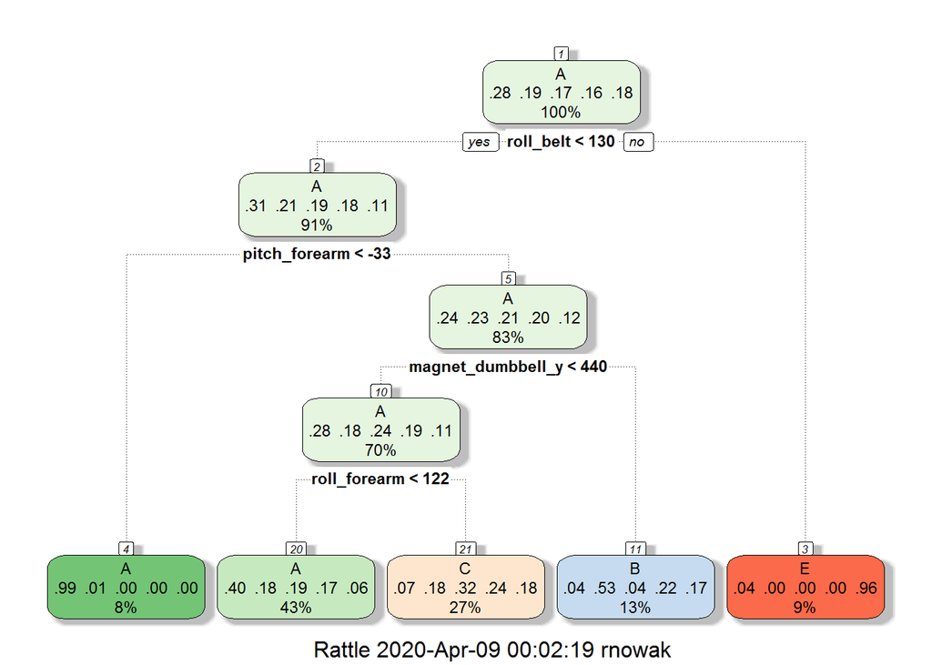

```r
mod_rpart <- train(classe ~., method="rpart", data=train[,c(8:60)])
fancyRpartPlot(mod_rpart$finalModel)
```

```r
mod_rpart <- predict(mod_rpart, test[,c(8:60)])
confusionMatrix(test$classe, mod_rpart)$overall[1]
```

```
##  Accuracy
## 0.4892099
```

Prediction Accuracy was 48.9%; try random forest algorithm

## Build Machine learning algorithm with random forest model; test accuracy of model

```r
mod_rf <- train(classe ~., method="rf", data=train[,c(8:60)])
pred_rf <-predict(mod_rf, test[,c(8:60)])
confusionMatrix(test$classe, pred_rf)$overall[1]
```

```
## Accuracy
## 0.995582
```

Prediction Accuracy with random forest is 99.6%

## Build Machine learning algorithm with boosting model; test accuracy of model

```r
mod_gbm <- train(classe ~., method= "gbm", data=train[,c(8:60)])
pred_gbm <-predict(mod_gbm, test[,c(8:60)])
confusionMatrix(test$classe, pred_gbm)$overall[1]
```

[output not shown]

## Build machine learning algorithm with LDA; test accuracy of model

```r
mod_lda <- train(classe ~., method="lda", data=train[,c(8:60)])
pred_lda <- predict(mod_lda, test[,c(8:60)])
confusionMatrix(test$classe, pred_lda)$overall[1]
```

```
##  Accuracy
## 0.7007647
```

Accuracy is 70.1%

Out of all the models the RF model has the highest prediction accuracy (99%). Next best model is the boosting model (96%), LDA (70%) and then decision tree model (49%).Therefore, choose Random forest model for prediction.

```r
error <- 1- as.numeric(confusionMatrix(test$classe, pred_rf)$overall[1])
error
```

```
## [1] 0.004418012
```

out of sample error is 0.4%

## Use RF model to predict 20 test cases

```r
predtest <- predict(mod_rf, pmltest[,c(8:60)] )
predtest
```

```
##  [1] B A B A A E D B A A B C B A E E A B B B
## Levels: A B C D E
```